# A3: Incarceration

### Introduction

My project analyzes a data set that consists of incarceration data in the United States of America, ranging from 1970 to 2018. The purpose of the project is to think about how incarceration varies by race in the U.S., look at trends in incarceration over time, and create a map that shows how the incarcerated population is distributed geographically.

### Summary Information

Analysis conducted on the data showed that 737126 people were incarcerated in 2018. Of these people, 46.95% were white, 33.58% were black, 15.38% were Latinx, 0.96% were Asian American and Pacific Islander, and 1.4% were Native American. However, in 2018, 60.32% of the US population was white, 13.48% was black, 18.59% was Latinx, 6.76% was Asian American and Pacific Islander, and 0.85% was Native American. The differences between these two percentage groups show that there is an imbalance in the United States’ criminal system, leading to significant overcriminalization for minorities.

### The Dataset

Who collected the data? The Vera Institute collected the data from a number of federal departments in the U.S..

How was the data collected or generated? The incarceration data was collected by the U.S. Department of Justice Bureau of Justice Statistics, and supplemented with data from state departments of correction when federal data was unavailable or missing. The population data was supplied by the U.S. Census Bureau and the Centers for Disease Control and Prevention, and the geographic data was supplied by the U.S. Department of Agriculture and Census Bureau.

Why was the data collected? The data was collected to study, expose, and end the overcriminalization and incarceration of people of color, people experiencing poverty, and immigrants. This was done with the goal of creating safe, healthy, empowered communities and a fair justice system.

How many observations (rows) are in your data? There are 153,811 observations in the data.

How many features (columns) are in the data? There are 121 features in the data.

What, if any, ethical questions or questions of power do you need to consider when working with this data?  
What are possible limitations or problems with this data?

The data is large and messy, and there are many missing values that limit the conclusions that can be drawn from certain locations or years. As a result of being removed from the collection of the data, I also need to ensure that I don’t suppress voices or exclude key information just to emphasize clarity and cleanliness in my visualizations. Finally, I have to recognize that the dataset is strongly related to racism and inequality in America, and I need to be careful to avoid bias in my analysis and conclusions.

### Trends Over Time Chart

This chart describes how the jail populations of different races in the United States changed from 1985 to 2018.

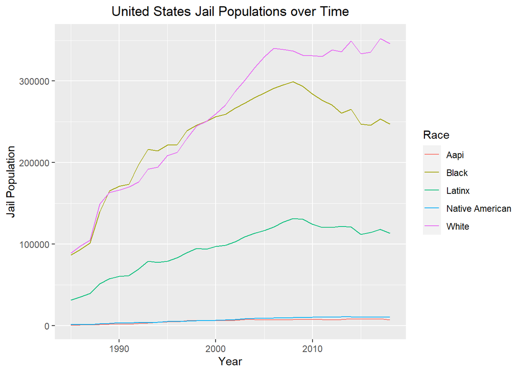

The chart shows that jail populations increased for each race from 1985 to 2006. During this time, white and black incarceration was rather similar, with Latinx incarceration at about 1/3 of them. However, after 2006, white incarceration stayed roughly the same, while black and Latinx incarceration both decreased. Relative to the other 3 plotted races, AAPI and Native American incarceration was low, but it still followed similar trends.

### Variable Comparison Chart

This chart shows the jail populations of different regions in the United States in 2018, and how different races are distributed in those regions.

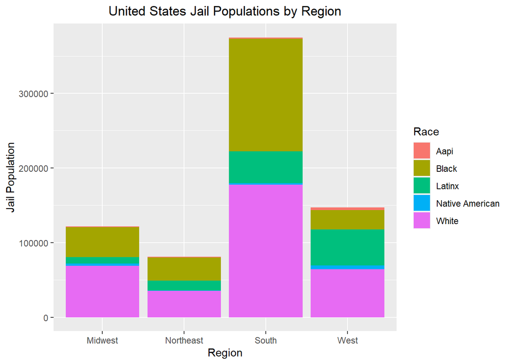

The chart shows that the region with the largest jailed population in the United States is by far the South, with roughly as many people in jail as the other three regions combined. The West and Midwest have relatively similar jailed populations, and the smallest population is in the Northeast. It also shows that the West has the highest relative proportion of jailed Latinx and AAPI people, and that the South holds roughly the same amount of white and black people in jail.

### Map

The following map shows the counties of the United States, with color corresponding to the amount of incarcerated individuals in that region.

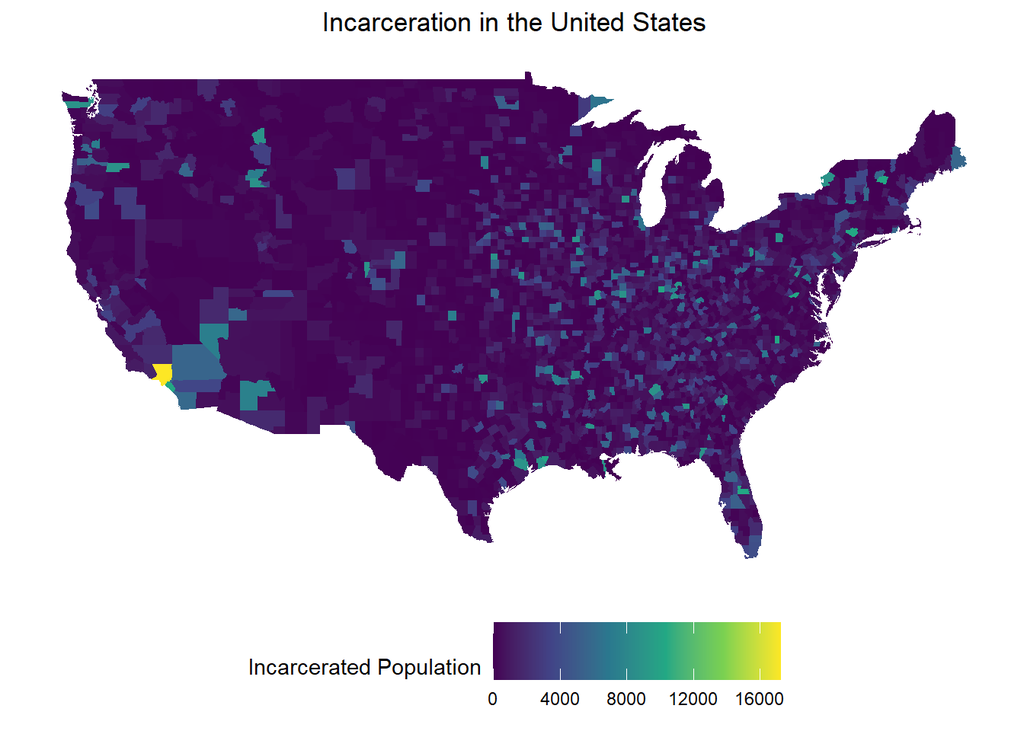